# CANTO - preprocessing

January 2, 2020

## Dataset

The original dataset in BI contains 9752 samples and 1014 columns.

## Bilateral and bifocal

- Bilateral:

```
##
##   no  yes <NA>
## 9510  227   15
```

We remove 227 bilateral cases and 15 NAs

We obtain 9510 samples.

- Bifocal:

```
##
##   no  yes
## 7514  886
```

We keep bifocal patients.

- Date of diagnosis

We have 413 patients with dates as NK/mm/yyyy. We set for them the diagnosis at 1st of the month. We still have dates like:

```
##  [1] "NK/NK/2012" "NK/NK/2012" "NK/NK/2012" "NK/NK/2012" "NK/NK/2012"
##  [6] "K"          "NK/NK/2012" "NK/NK/2012" "NK/NK/2012" "NK/NK/2012"
## [11] "NK/NK/2012" "NK/NK/2013" "NK/NK/2013" "NK/NK/2013" "K"
## [16] "NK/NK/2013" "NK/NK/2016" "NK/NK/2013" "NK/NK/2013" "K"
## [21] "NK/NK/2013" "NK/NK/2013" "NK/NK/2014" "NK/NK/2014" "NK/NK/2014"
## [26] "NK/NK/2014" "NK/NK/2014" "K"          "NK/NK/2015" "K"
## [31] "NK/NK/2015" "NK/NK/2015" "NK/NK/2015" "K"          "NK/NK/2015"
## [36] "K"          "NK/NK/2015" "K"          "K"          "K"
## [41] "NK/NK/2015" "NK/NK/2015" "K"          "K"          "NK/NK/2015"
## [46] "NK/NK/2015" "K"          "NK/NK/2015" "NK/NK/2015" "NK/NK/2013"
## [51] ""           "NK/NK/2012" "NK/NK/2012" "K"          "K"
## [56] "K"          "NA/NA/2012" "NA/NA/2012" "NK/NK/2013" "NK/NK/2013"
## [61] "NK/NK/2015" "K"          "K"          "K"          "NK/NK/2013"
## [66] "NK/NK/2013" "NK/NK/2015" "K"          "K"          "K"
## [71] "K"          "K"          "NK/NK/2013" "NK/NK/2016" "NK/NK/2016"
## [76] "K"          "D"          "ND/ND/2013" "NK/NK/2014"
```

We do not remove bifocal patients.

## BMI

We have 0 patients with missing BMI

## Tumor characteristics - biopsy

We have 54 patients with unilateral cancer but with data for both left and right breast (we have 29 columns for biopsy for each breast). Here the table for biopsy related variables for these patients. Odd rows correspond to the left breast, even rows to the right breast (in this table we hence have 2 times the number of samples with data for both left and right breast):

| ID | OFFICIAL SIDE | INSPECTED SIDE | # NOT NA | form | tuicc | tuicc_5cl | tuicc_4cl | tuicc_3cl | tuicc_3cl_2 | nuicc | nuicc_2cl | nuicc_4cl | mat_type | invasive_biop | histo_4cl_biop | histo_3cl_biop | index_mitotic_biop | dcis_biop | grade_3cl_biop | grade_2cl_biop | biopsy | er_biop | perc_er_biop | inte_er_biop | pr_biop | perc_pr_biop | inte_pr_biop | her2_biop | her2_ihc_biop | … |
| --- | --- | --- | --- | --- | --- | --- | --- | --- | --- | --- | --- | --- | --- | --- | --- | --- | --- | --- | --- | --- | --- | --- | --- | --- | --- | --- | --- | --- | --- | --- |
| 19 | R | L | 1 | NA | NA | NA | NA | NA | NA | NA | NA | NA | NA | 2 | NA | NA | NA | NA | NA | NA | NA | NA | NA | NA | NA | NA | NA | NA | NA | … |
| 19 | R | R | 20 | 2 | NA | NA | NA | NA | NA | 1 | 1 | 1 | 1 | 2 | 1 | 1 | NA | 2 | 2 | 1 | 2 | 1 | 30 | 1 | 1 | 30 | 1 | 1 | 4 | … |
| 21 | L | L | 14 | 1 | 12 | 2 | 1 | 1 | 1 | 1 | 1 | 1 | 3 | 2 | NA | NA | NA | NA | NA | NA | 1 | 1 | NA | NA | 1 | NA | NA | NA | NA | … |
| 21 | L | R | 1 | NA | NA | NA | NA | NA | NA | NA | NA | NA | NA | 1 | NA | NA | NA | NA | NA | NA | NA | NA | NA | NA | NA | NA | NA | NA | NA | … |
| 24 | L | L | 9 | 1 | NA | NA | NA | NA | NA | 1 | 1 | 1 | 3 | 2 | NA | NA | NA | NA | NA | NA | 1 | 1 | NA | NA | 1 | NA | NA | NA | NA | … |
| 24 | L | R | 1 | NA | NA | NA | NA | NA | NA | NA | NA | NA | NA | 1 | NA | NA | NA | NA | NA | NA | NA | NA | NA | NA | NA | NA | NA | NA | NA | … |
| 28 | R | L | 1 | NA | NA | NA | NA | NA | NA | NA | NA | NA | NA | 1 | NA | NA | NA | NA | NA | NA | NA | NA | NA | NA | NA | NA | NA | NA | NA | … |
| 28 | R | R | 9 | 1 | NA | NA | NA | NA | NA | 1 | 1 | 1 | 3 | 2 | NA | NA | NA | NA | NA | NA | 1 | 1 | NA | NA | 1 | NA | NA | NA | NA | … |
| 31 | R | L | 1 | NA | NA | NA | NA | NA | NA | NA | NA | NA | NA | 1 | NA | NA | NA | NA | NA | NA | NA | NA | NA | NA | NA | NA | NA | NA | NA | … |
| 31 | R | R | 14 | 1 | 0 | 1 | 1 | 1 | 1 | 1 | 1 | 1 | 3 | 2 | NA | NA | NA | NA | NA | NA | 1 | 1 | NA | NA | 1 | NA | NA | NA | NA | … |

[output cut: 98 more lines]

We need to pay attention to some patients, some of theme seem to be bilateral??

```
##
##           0    1
##   L    4830    0
##   R    4626    0
##   <NA>    0   54
```

We also have 0 individuals with no information on right or left side. We keep the side as the one saved in variable LOC.

## Surgery

```
##       Info both L/R
## SIDE      0    1
##   L    4802    0
##   R    4595    0
##   <NA>   91   22
```

We have 91 individuals with unilateral cancer with no information on left or right breast and 22 individuals with informations on both sides but with unilateral cancer. We inspect values forleft and right, as we have done for biposy:

| ID | OFFICIAL SIDE | INSPECTED SIDE | # NOT NA | pT | pN | nbggpos | taillehisto | multifocal | infiltrant_cancer_surg | histo_4cl_surg | histo_3cl_surg | grade_3cl_surg | grade_2cl_surg | index_mitotic_surg | dcis_surg | surgery | breast_surgery | axillary_surgery | comp_post_surg | er_surg | perc_er_surg | inte_er_surg | pr_surg | perc_pr_surg | inte_pr_surg | her2_surg | her2_ihc_surg | Ki67_surg_bi | Ki67_surg | … |
| --- | --- | --- | --- | --- | --- | --- | --- | --- | --- | --- | --- | --- | --- | --- | --- | --- | --- | --- | --- | --- | --- | --- | --- | --- | --- | --- | --- | --- | --- | --- |
| 5 | R | L | 1 | NA | NA | NA | NA | NA | NA | NA | NA | NA | NA | NA | NA | NA | NA | NA | 1 | NA | NA | NA | NA | NA | NA | NA | NA | NA | NA | … |
| 5 | R | R | 22 | 1 | 0 | 0 | 12 | 1 | 2 | 1 | 1 | 2 | 1 | 2 | 2 | 2 | 1 | 2 | 1 | NA | NA | NA | NA | NA | NA | 2 | 3 | 2 | 15 | … |
| 440 | L | L | 18 | 2 | 0 | 0 | 22 | 1 | 2 | 1 | 1 | 3 | 2 | 2 | 2 | 2 | 1 | 2 | 1 | NA | NA | NA | NA | NA | NA | NA | NA | 1 | NA | … |
| 440 | L | R | 4 | NA | NA | NA | NA | NA | NA | NA | NA | NA | NA | NA | NA | 2 | 1 | 4 | 1 | NA | NA | NA | NA | NA | NA | NA | NA | NA | NA | … |
| 625 | L | L | 17 | 2 | 1 | 2 | 40 | 1 | 2 | 1 | 1 | 2 | 1 | 3 | 2 | 2 | 2 | 1 | 1 | NA | NA | NA | NA | NA | NA | NA | NA | NA | NA | … |
| 625 | L | R | 3 | NA | NA | NA | NA | NA | NA | NA | NA | NA | NA | NA | NA | NA | 2 | 1 | 1 | NA | NA | NA | NA | NA | NA | NA | NA | NA | NA | … |
| 999 | R | L | 22 | 1 | 1 | 2 | 6 | 1 | 2 | 4 | 3 | 3 | 2 | 2 | 2 | 2 | 2 | 3 | 1 | 2 | NA | NA | 2 | NA | NA | 2 | 1 | 1 | NA | … |
| 999 | R | R | 23 | 1 | 0 | 0 | 10 | 1 | 2 | 1 | 1 | 3 | 2 | 2 | 2 | 2 | 1 | 2 | 1 | 1 | NA | 3 | 2 | NA | NA | 1 | 4 | 1 | NA | … |
| 1886 | L | L | 28 | 1 | 0 | 0 | 11 | 1 | 2 | 1 | 1 | 2 | 1 | 1 | 2 | 2 | 1 | 2 | 1 | 1 | 100 | 3 | 1 | 100 | 3 | 2 | 1 | 2 | 15 | … |
| 1886 | L | R | 1 | NA | NA | NA | NA | NA | NA | NA | NA | NA | NA | NA | NA | 1 | NA | NA | NA | NA | NA | NA | NA | NA | NA | NA | NA | NA | NA | … |

[output cut: 34 more lines]

As you can see, we can assign them to the correct side reported as variable “LOC”, the few wrong side columns are probably filled as an error. We now have only the 91 patients with no information on surgery variables. These patients will not be used to fill information on surgery variables.

```
##       Info both L/R
## SIDE      0    1
##   L    4802    8
##   R    4595   14
##   <NA>   91    0
```

We also have 1 patient with a right breast biopsy but a left breast surgery, his original side is set to left. DO we change all variables related to right biopsy as left biopsy or is it an urgent surgery on the other side??

```
##       SURGERY
## BIOPSY    L    R <NA>
##      L 4809    0   48
##      R    1 4609   43
```

## Chemotherapy

Chemotherapy status:

```
##
##   no  yes <NA>
## 4483 4921  106
```

We have 106 patients with NA as chemotherapy status, counting both neoadj and adj. Only 1 of them has missing chimio status (NA) with information on chemotherapy, see table:

|  | CHIMIOADJ | SEQCHIMIO_ADJ | SEQ1_ADJ | SEQ2_ADJ | OTHSEQ1_ADJ | OTHSEQ2_ADJ | REDUCDOSE_ADJ | FACTCROISS_ADJ | CHIMIONEO | SEQCHIMIO_NEO | SEQ1_NEO | SEQ2_NEO | OTHSEQ1_NEO | OTHSEQ2_NEO | REDUCDOSE_NEO | FACTCROISS_NEO | SATALOFF1_G_M0 | SATALOFF2_G_M0 | SATALOFF1_D_M0 | SATALOFF2_D_M0 |
| --- | --- | --- | --- | --- | --- | --- | --- | --- | --- | --- | --- | --- | --- | --- | --- | --- | --- | --- | --- | --- |
| 3123 | NA | NA | NA | NA | NA | NA | NA | NA | 0 | NA | NA | NA | NA | NA | NA | NA | NA | NA | NA | NA |

Since there is only 1 column different from NA, and it is set to 0, we can set chemotherapy to no for all NAs.

We now have:

```
##
##   no  yes
## 4589 4921
```

We plot the number of variables for which we have information on chemotherapy with respect to the chemotherapy status (to control for patients set as no chemotherapy but with information on chemotherapy, neo-adjuvant or adjuvant):

```
##
##        no  yes
##   0   105    0
##   1  4403    0
##   2    37    2
##   3     5    0
##   4     1    4
##   5     0   19
##   6     2  357
##   7     3 2810
##   8     6  733
##   9    20  760
##   10    6  184
##   11    1   21
##   12    0    4
##   13    0    7
##   14    0   14
##   15    0    6
```

|  | CHIMIOADJ | SEQCHIMIO_ADJ | SEQ1_ADJ | SEQ2_ADJ | OTHSEQ1_ADJ | OTHSEQ2_ADJ | REDUCDOSE_ADJ | FACTCROISS_ADJ | CHIMIONEO | SEQCHIMIO_NEO | SEQ1_NEO | SEQ2_NEO | OTHSEQ1_NEO | OTHSEQ2_NEO | REDUCDOSE_NEO | FACTCROISS_NEO | SATALOFF1_G_M0 | SATALOFF2_G_M0 | SATALOFF1_D_M0 | SATALOFF2_D_M0 |
| --- | --- | --- | --- | --- | --- | --- | --- | --- | --- | --- | --- | --- | --- | --- | --- | --- | --- | --- | --- | --- |
| 52 | 0 | NA | NA | NA | NA | NA | NA | NA | 1 | 2 | 1 | 5 | NA | NA | 0 | 0 | NA | NA | T-D | NA |
| 170 | 0 | NA | NA | NA | NA | NA | NA | NA | 1 | 2 | 1 | 5 | NA | NA | 0 | 0 | NA | NA | T-A | N-A |
| 228 | 0 | NA | NA | NA | NA | NA | NA | NA | 1 | 2 | 1 | 5 | NA | NA | 0 | 0 | NA | NA | T-A | N-A |
| 843 | 0 | NA | NA | NA | NA | NA | NA | NA | 0 | NA | NA | NA | NA | NA | NA | NA | NA | NA | NA | NA |
| 1076 | 0 | NA | NA | NA | NA | NA | NA | NA | 0 | NA | NA | NA | NA | NA | NA | NA | NA | NA | NA | NA |
| 1220 | 0 | NA | NA | NA | NA | NA | NA | NA | 0 | NA | NA | NA | NA | NA | NA | NA | NA | NA | NA | NA |
| 1262 | 0 | NA | 6 | NA | NA | NA | NA | NA | 0 | NA | NA | NA | NA | NA | NA | NA | NA | NA | NA | NA |
| 1483 | 0 | NA | NA | NA | NA | NA | NA | NA | 0 | NA | NA | NA | NA | NA | NA | NA | NA | NA | NA | NA |
| 1783 | 1 | 2 | 1 | 6 | NA | PACLITAXEL HEBDOMADAIRE | 1 | 0 | 0 | NA | NA | NA | NA | NA | NA | NA | NA | NA | NA | NA |
| 1931 | 0 | NA | NA | NA | NA | NA | NA | NA | 0 | NA | NA | NA | NA | NA | NA | NA | NA | NA | NA | NA |

[output cut: 71 more lines]

We have 16 patients for which SATALOFF1_G_M0 is defined and 1 patient with defined SEQ2_ADJ but SEQ1_ADJ set to NA. We set these patients as having had chemotherapy and also respectively having neoadjuvant and adjuvant chemotherapies.

### Adjuvant chemotherapy

Chemotherapy status:

```
##   no  yes NA's
## 5780 3727    3
```

We have 3 patients with NAs on adjuvant chemotherapy status.

The adjuvant chemotherapy variables for these 3 patients are:

|  | CHIMIONEO | adj_bin | CHIMIOADJ | SEQCHIMIO_ADJ | SEQ1_ADJ | SEQ2_ADJ | OTHSEQ1_ADJ | OTHSEQ2_ADJ | REDUCDOSE_ADJ | FACTCROISS_ADJ |
| --- | --- | --- | --- | --- | --- | --- | --- | --- | --- | --- |
| 1282 | 1 | NA | NA | NA | NA | NA | NA | NA | NA | NA |
| 2008 | 1 | NA | NA | NA | NA | NA | NA | NA | NA | NA |
| 3315 | 1 | NA | NA | NA | NA | NA | NA | NA | NA | NA |

We can impute no adj chemotherapy for these patients. We now have:

```
##   no  yes
## 5783 3727
```

Here the distribution of adjuvant chemotherapy regimen:

```
## anthra-taxans        anthra       taxanes        others          NA's
##          2670           154           103           793             7
```

See the values for patients with adj_regimen = NA

|  | adj_bin | CHIMIOADJ | SEQCHIMIO_ADJ | SEQ1_ADJ | SEQ2_ADJ | OTHSEQ1_ADJ | OTHSEQ2_ADJ | REDUCDOSE_ADJ | FACTCROISS_ADJ |
| --- | --- | --- | --- | --- | --- | --- | --- | --- | --- |
| 401 | yes | 1 | NA | 6 | 6 | NK | NK | 0 | NA |
| 636 | yes | 1 | NA | NA | NA | NA | NA | NA | NA |
| 1164 | yes | 1 | 2 | 6 | 6 | TAXOL | CYCLOPHOSPHAMIDE | 0 | 0 |
| 1671 | yes | 1 | 2 | 6 | 4 | EC 100 | NA | 0 | 1 |
| 5503 | yes | 1 | NA | 6 | NA | TAXOTERE + ENDOXAN | NA | 1 | 1 |
| 5631 | yes | 1 | NA | 1 | 5 | NA | NA | NA | NA |
| 7086 | yes | 1 | 2 | 6 | 6 | TAXOL | HERCEPTINE | 0 | 0 |

We move the sample to regimens = “others”

Here the new distribution of adjuvant chemotherapy regimen:

```
## anthra-taxans        anthra       taxanes        others          NA's
##          2670           154           103           798             2
```

### Neo-adjuvant chemotherapy

```
##   no  yes
## 8257 1253
```

We have no NAs for neo-adjuvant chemotherapy

Here the distribution of neo-adjuvant chemotherapy regimens:

```
## anthra-taxans        anthra       taxanes        others          NA's
##           945            16            22           154           116
```

A table plot of neo-adjuvant chemotherapy versus adjuvant chemotherapy:

```
##      ADJ
## NAC     no  yes
##   no  4572 3685
##   yes 1211   42
```

Here the ditribution of incopatible breast sides on “breast_res_insitu”,“breast_res_infiltr_tmp” and “nb_nodes_pos” :

```
##
##    0    1
## 9503    7
```

There are 7 patients with incompatible information on right/left for neoadj chemotherapy.

```
##    L    R NA's
##  652  571   30
```

We have 30 patients with missing information on their relative side on variables regarding “breast_res_insitu”, “reast_res_infiltr” and “nb_nodes_pos”

## Radiotherapy

Distribution of radiotherapy:

```
##   no  yes NA's
##  838 8554  118
```

## Hormonotherapy

Data distribution:

```
##   no  yes NA's
## 1818 7536  156
```

We have 156 patients with hormonotherapy status set to NA. Only 2 people have information on hormonotherapy variables:

|  | HORM1 | HORM2 | HORM3 | HORM4 | HORM5 | HORM6 | HORM7 | DTDEBHORM1 | DTDEBHORM2 | DTDEBHORM3 | DTDEBHORM4 | DTDEBHORM5 | DTDEBHORM6 | DTDEBHORM7 |
| --- | --- | --- | --- | --- | --- | --- | --- | --- | --- | --- | --- | --- | --- | --- |
| 3540 | 2 | NA | NA | NA | NA | NA | NA | NK/06/2016 |  |  |  |  |  |  |
| 4521 | 1 | NA | NA | NA | NA | NA | NA | 04/05/2016 |  |  |  |  |  |  |

We set the hormonotherapy status of patients with status = NA to no, except for the patients seen above, for which we set the hormonotherapy status to yes.

The hormonotherapy status is now distributed as:

```
##   no  yes
## 1972 7538
```

Here a table for patients with information on hormonotherapy variables and the corresponding hormonotherapy status (to check for patients with hormonotherapy status = no but information on hormonotherapy):

```
##
##       no  yes
##   0 1968   41
##   1    2 6002
##   2    2 1107
##   3    0  314
##   4    0   55
##   5    0   17
##   6    0    1
##   7    0    1
```

We have 4 patients with information on hormonotherapy with declared no hormonotherapy

|  | HORM1 | HORM2 | HORM3 | HORM4 | HORM5 | HORM6 | HORM7 | DTDEBHORM1 | DTDEBHORM2 | DTDEBHORM3 | DTDEBHORM4 | DTDEBHORM5 | DTDEBHORM6 | DTDEBHORM7 |
| --- | --- | --- | --- | --- | --- | --- | --- | --- | --- | --- | --- | --- | --- | --- |
| 400 | 1 | NA | NA | NA | NA | NA | NA | NK/11/2014 |  |  |  |  |  |  |
| 1658 | 5 | 4 | NA | NA | NA | NA | NA | NK/08/2016 | NK/11/2016 |  |  |  |  |  |
| 3243 | 3 | 4 | NA | NA | NA | NA | NA | NK/09/2013 | NK/02/2014 |  |  |  |  |  |
| 6809 | 2 | NA | NA | NA | NA | NA | NA | NK/10/2013 |  |  |  |  |  |  |

We change their hormonotherapy status from no to yes. The hormonotherapy status is now distributed as:

```
##   no  yes
## 1968 7542
```

The distributionof of the type of the first hormonotherapy is:

```
##           tamoxifen aromatase inhibitor              others                NA's
##                2925                4376                  79                 162
```

## TARGET THERAPY

- Herceptine

```
##   no  yes
## 8374 1136
```

There are no NAs for herceptine status.

Here a table representing the variables regarding herceptine for people having herceptine set to no but information on herceptine (test the correctness of no herceptine):

```
##
##       no  yes
##   0 8371    8
##   1    0    2
##   2    3 1126
```

|  | DTDEBHERCEP | NBCYCLHERCEP | SCHEMAHERCEP | VOIEHERCEP | DOSE1HERCEP |
| --- | --- | --- | --- | --- | --- |
| 6317 | NK/NK/2014 | 18 | 2 | 1 | NA |
| 6904 |  | NA | NA | NA | NA |
| 9490 | 18/10/2016 | 16 | 2 | 1 | NA |

```
##   no  yes
## 8371 1139
```

- Other targer therapy:

```
##   no  yes NA's
## 9124  277  109
```

We have 109 NAs, see their infotmation

|  | NOMCIBLE1 | DTDEBCIBLE1 | NBCIBLE1 | POSOCIBLE1 |
| --- | --- | --- | --- | --- |
| 15 |  |  | NA | NA |
| 49 |  |  | NA | NA |
| 97 |  |  | NA | NA |
| 179 |  |  | NA | NA |
| 282 |  |  | NA | NA |
| 291 |  |  | NA | NA |
| 301 |  |  | NA | NA |
| 316 |  |  | NA | NA |
| 322 |  |  | NA | NA |
| 326 |  |  | NA | NA |

[output cut: 99 more lines]

In this case NAs values are to set to NO. The other targer therapy status distribution is now:

```
##   no  yes
## 9233  277
```

## PATH

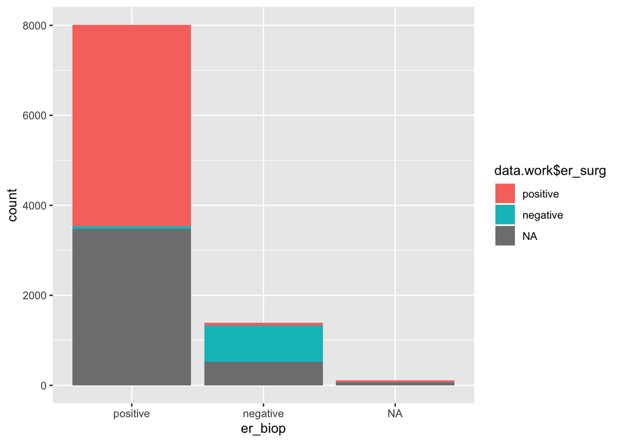

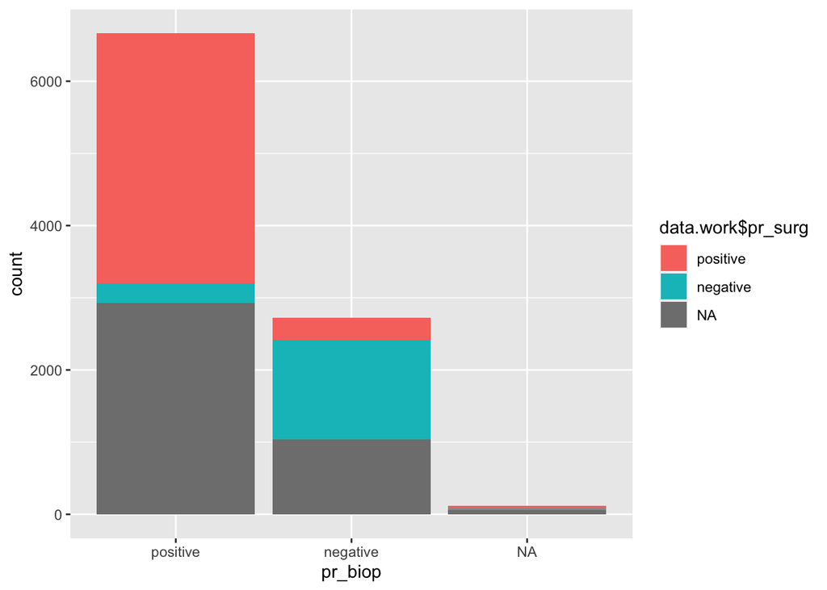

We have 11 patients with surgery but without the surgery date

|  | surg | DTTUMOR_G | DTTUMOR_D | DTQUADRA_G | DTQUADRA_D | DTMASTR_G | DTMASTR_D | DTMASTSC_G | DTMASTSC_D | DTCURAGE_G | DTCURAGE_D | DTGANGLS_G | DTGANGLS_D |
| --- | --- | --- | --- | --- | --- | --- | --- | --- | --- | --- | --- | --- | --- |
| 420 | yes |  |  |  |  |  |  |  |  |  | 2014-07-23 |  |  |
| 548 | yes |  |  |  |  |  |  |  |  |  | 2014-07-15 |  |  |
| 727 | yes |  |  |  |  |  |  |  |  | 2015-05-21 |  |  |  |
| 1158 | yes |  |  |  |  |  |  |  |  |  |  |  |  |
| 2451 | yes |  |  |  |  |  |  |  |  | 2013-05-03 |  | 2013-05-03 |  |
| 4524 | yes |  |  |  |  |  |  |  |  |  |  |  | 2015-10-07 |
| 4694 | yes |  |  |  |  |  |  |  |  |  | 2017-02-24 |  |  |
| 6934 | yes |  |  |  |  |  |  |  |  |  | 2014-08-14 |  |  |
| 8116 | yes |  |  |  |  |  |  |  |  |  |  | 2016-03-22 |  |
| 8981 | yes |  |  |  |  |  |  |  |  |  |  | 2014-10-09 |  |

[output cut: 1 more lines]

See path info:

```
## surgery     NAC  others    NA's
##    7946    1253     185     126
```

We have 126 NAs values. See variables related to these patients to look for inconsistencies:

|  | data.work[which(is.na(data.work$parcours)), c("surgery")] | date_surg | NAC_bin | NAC_regimen | DTDEBCYCLE_NEO | DTFINCYCLE_NEO | adj_bin | adj_regimen | DTDEBCYCLE_ADJ | DTFINCYCLE_ADJ | min_date_chimio_hormono_hercep_TC | DTDEBCIBLE1 | DTDEBHERCEP | min_date_hormono_hercep_TC | min_date_hormono |
| --- | --- | --- | --- | --- | --- | --- | --- | --- | --- | --- | --- | --- | --- | --- | --- |
| 15 | NA |  | no | NA |  |  | no | NA |  |  |  |  |  |  |  |
| 49 | NA |  | no | NA |  |  | no | NA |  |  |  |  |  |  |  |
| 97 | NA |  | no | NA |  |  | no | NA |  |  |  |  |  |  |  |
| 166 | NA |  | no | NA |  |  | no | NA |  |  |  |  |  |  |  |
| 282 | NA |  | no | NA |  |  | no | NA |  |  |  |  |  |  |  |
| 291 | NA |  | no | NA |  |  | no | NA |  |  |  |  |  |  |  |
| 301 | NA |  | no | NA |  |  | no | NA |  |  |  |  |  |  |  |
| 316 | NA |  | no | NA |  |  | no | NA |  |  |  |  |  |  |  |
| 322 | NA |  | no | NA |  |  | no | NA |  |  |  |  |  |  |  |
| 326 | NA |  | no | NA |  |  | no | NA |  |  |  |  |  |  |  |

[output cut: 116 more lines]

We also have 69 patients with surgery date after adjuvant treatment. Is it a neoadj chemotherapy?

|  | date_surg | adj_bin | DTDEBCYCLE_ADJ | NAC_bin | DTDEBCYCLE_NEO | min_date_chimio_hormono_hercep_TC | min_date_hormono_hercep_TC | DTDEBCIBLE1 | DTDEBHERCEP | min_date_hormono | adj_regimen |
| --- | --- | --- | --- | --- | --- | --- | --- | --- | --- | --- | --- |
| 82 | 2013-06-04 | yes | 2012-10-23 | no |  | 2012-10-23 | 2013-03-01 |  |  | 2013-03-01 | anthra-taxans |
| 198 | 2013-07-30 | yes | 2013-02-04 | yes | 2013-02-04 | 2013-02-04 | 2013-11-01 |  |  | 2013-11-01 | anthra-taxans |
| 335 | 2014-06-26 | yes | 2013-09-12 | no |  | 2013-09-12 | 2013-11-14 |  | 2013-11-14 |  | anthra-taxans |
| 380 | 2014-09-11 | yes | 2014-01-15 | no |  | 2014-01-15 | 2014-05-29 |  |  | 2014-05-29 | anthra-taxans |
| 392 | 2014-05-28 | yes | 2013-12-05 | yes |  | 2013-12-05 | 2014-09-01 |  |  | 2014-09-01 | anthra-taxans |
| 529 | 2015-06-05 | yes | 2014-08-13 | no |  | 2014-08-13 | 2015-02-17 |  |  | 2015-02-17 | anthra-taxans |
| 909 | 2015-05-20 | yes | 2015-05-19 | no |  | 2015-05-06 | 2015-05-06 | 2015-05-06 |  | 2015-12-01 | anthra-taxans |
| 972 | 2015-06-24 | yes | 2015-01-05 | no |  | 2015-01-05 | 2016-03-30 |  |  | 2016-03-30 | anthra-taxans |
| 1006 | 2017-07-31 | yes | 2015-10-09 | no |  | 2015-10-09 | 2016-10-19 |  |  | 2016-10-19 | anthra-taxans |
| 1040 | 2015-09-02 | yes | 2015-01-30 | no |  | 2015-01-30 | 2016-05-31 |  |  | 2016-05-31 | anthra-taxans |

[output cut: 59 more lines]

- DCIS/Invasive status

```
##     dcis only invasive only dcis+invasive          NA's
##             1          3655          5833            21
```

3 individuals with negative dcis and invasive -> ?

```
## dcis only  invasive      NA's
##         1      9488        21
```

- ER status for invasive case

```
## positive negative     NA's
##     8098     1340       72
```

ER and PR percentage for invasive case, intensity of right side at biopsy (INTENSRE_D_BI) is not present

72 individuals with missing ER status:

- 21 with missing invasive/dcis status
- 50 with invasive status : 47 individuals with missing ER status for surgery and biop, 3 individual with negative, positive, negative ER status for surgery -> ?

PR status for invasive case

```
## positive negative     NA's
##     6976     2458       76
```

76 individuals with missing PR status:

- 21 with missing invasive/dcis status
- 54 with invasive status : 0 individuals with missing PR status for surgery and biop

Her2 status for invasive case

```
## positive negative     NA's
##     1417     7934      159
```

- Subtypes

```
##   HER2+    TNBC luminal    NA's
##    1417     914    7014     165
```

```
## Her2+/HR- Her2+/HR+      TNBC   luminal      NA's
##       361      1055       914      7014       166
```

We define pcr as no infiltrating tumor in the breast and no cancer in limphatic nodes

|  | surgery | breast_res_insitu | breast_res_infiltr_tmp | ENVAHI_D_M0 | ENVAHI_G_M0 | RESIDU1_D_M0 | RESIDU1_G_M0 |
| --- | --- | --- | --- | --- | --- | --- | --- |
| 44 | yes | yes | NA | NA | 0 | NA | NA |
| 150 | yes | no | NA | 0 | NA | NA | NA |
| 164 | yes | yes | NA | NA | 0 | NA | NA |
| 462 | yes | no | NA | NA | 0 | NA | NA |
| 525 | yes | yes | NA | NA | 0 | NA | NA |
| 535 | yes | no | NA | NA | 0 | NA | NA |
| 540 | yes | no | NA | NA | 0 | NA | NA |
| 573 | yes | yes | NA | NA | 0 | NA | NA |
| 753 | yes | yes | NA | 0 | NA | NA | NA |
| 809 | yes | no | NA | 0 | NA | NA | NA |

[output cut: 21 more lines]

Department and region

```
##  01  02  03  04  05  06  07  08  09  10  11  12  13  14  15  16  17  18  19  21
##  54 154  44  10   9  97  36  63  11  57  17  10 150 330  18  17  41  33  12 517
##  22  23  24  25  26  27  28  29  2A  2B  30  31  32  33  34  35  36  37  38  39
##  22  12  76   5  46 175  44   5   7   3  30  38  11 240  55  83   1   6 124  76
##  40  41  42  43  44  45  46  47  48  49  50  51  52  53  54  55  56  57  58  59
##  19  16  28  24 157  68   9  37  14 321 102 217 104  42 396  81  30 116 123 405
##  60  61  62  63  64  65  66  67  68  69  70  71  72  73  74  75  76  77  78  79
##  72  60 193 115  10   3   2  68   4 232  25 120  47  11  37 454 220 278 323  34
##  80  81  82  83  84  85  86  87  88  89  90  91  92  93  94  95 971 974  99
##  14   7  10  91  43  28   4   3 184 157  13 482 423 152 424 110   2   1   6
```

```
##
##                   Alsace                Aquitaine                 Auvergne
##                       72                      382                      201
##          Basse-Normandie                Bourgogne                 Bretagne
##                      390                      917                      140
##                   Centre                Champagne                    Corse
##                      168                      441                       10
##                 Etranger            Franche-Comté               Guadeloupe
##                        6                      119                        2
##          Haute-Normandie            Ile-de-France               La reunion
##                      395                     2646                        1
##                Languedoc                 Limousin                 Lorraine
##                      118                       27                      777
##            Midi-Pyrénées                     Nord                Normandie
##                       99                      598                      102
##         Pays-de-la-Loire                 Picardie          Poitou-Charente
##                      595                      240                       96
## Provence-Alpes-Côte Azur              Rhône-Alpes
##                      400                      568
```

Survival analysis

Check data in the derived variables